# DTRA_EpiArchive_Data-Influenza -CaseStudy(003)

```python
import numpy as np
import matplotlib.pyplot as plt
import pandas as pd
from datetime import datetime
from sklearn import preprocessing
from keras import models
from keras import layers
from keras.models import Sequential
from keras.layers import Dense
from keras.layers import LSTM
from sklearn.preprocessing import MinMaxScaler
from sklearn.metrics import mean_squared_error
import math
import requests
import json
from keras.datasets import mnist


%matplotlib inline
```

Important note about using TensorBoard:

- I downloaded all the dependencies like the `dcast` package

Here's what you need to type into the Terminal:

- C02V40QSHTDG:Scripts catherineordun$ cd log
- C02V40QSHTDG:log catherineordun$ ls dogsvscats-0.001--8conv-basic-video.model pertussis_lstm pertussis_gru pertussis_lstm_dropout pertussis_gru_adv pertussis_lstm_stateful pertussis_gru_adv_dropout
- CC02V40QSHTDG:log catherineordun$ tensorboard --logdir=pertussis_lstm_stateful
- Starting TensorBoard 47 at http://0.0.0.0:6006

**U.S. Texas Gonorrhea**

```python
tx_gon = "https://epiarchive.bsvgateway.org/api/case-count-by-interval/?region_id=228&disease=385&start=01/01/2006&end=10/02/2017"
```

```python
response = requests.get(tx_gon)
data = response.json()
print(data)
print(len(data))
#convert json to dataframe, then dataframe to array to matrix
tx_gon = pd.DataFrame.from_dict(data, orient='columns')
print(tx_gon.head())
```

**U.S. Texas Salmonellosis**

```python
tx_sal = " https://epiarchive.bsvgateway.org/api/case-count-by-interval/?region_id=228&disease=397&start=01/01/2006&end=10/02/2017"
```

```python
response = requests.get(tx_sal)
data = response.json()
print(data)
print(len(data))
#convert json to dataframe, then dataframe to array to matrix
tx_sal = pd.DataFrame.from_dict(data, orient='columns')
print(tx_sal.head())
```

**U.S. Texas Pertussis**

```python
tx_pert = "https://epiarchive.bsvgateway.org/api/case-count-by-interval/?region_id=228&disease=394&start=01/01/2006&end=10/02/2017"
```

```python
response = requests.get(tx_pert)
data = response.json()
print(data)
print(len(data))
#convert json to dataframe, then dataframe to array to matrix
tx_pert = pd.DataFrame.from_dict(data, orient='columns')
```

```python
tx_pert.head()
```

**U.S. Texas Influenza**

```python
tx_flu = "https://epiarchive.bsvgateway.org/api/case-count-by-interval/?region_id=228&disease=386&start=01%2F01%2F2006&end=10%2F02%2F2017"
```

```python
response = requests.get(tx_flu)
data = response.json()
print(data)
print(len(data))
#convert json to dataframe, then dataframe to array to matrix
tx_flu = pd.DataFrame.from_dict(data, orient='columns')
tx_flu.head()
```

```python
#Merge
r1 = pd.merge(tx_flu, tx_pert, how='left', on='interval__start_time')
```

```python
r1.head()
```

```python
r2 = pd.merge(r1, tx_sal, how='left', on='interval__start_time')
r2.head()
```

```python
r3 = pd.merge(r2, tx_gon, how='left', on='interval__start_time')
```

```python
r3.dtypes
```

```python
r3.drop(['interval__start_time', 'interval__end_time_y'], axis=1, inplace=True)
r3.head()
```

```python
r3.columns.values[0] = 'influenza'
r3.columns.values[2] = 'pertussis'
r3.columns.values[3] = 'salm'
r3.columns.values[5] = 'gon'
```

```python
r3.to_csv("/Users/catherineordun/Desktop/r3.csv")
```

```python
#read back in
disease = pd.read_csv("/Users/catherineordun/Desktop/r3.csv", index_col = False)
disease['end_week'] = disease['end_week'].apply(lambda x: x.split('T')[0])
print(disease['end_week'])
```

Datetime conversion because I need to select 2007+

```python
#convert dates to datetime
disease['end_week'] = disease['end_week'].apply(str)
disease['end_week'] = pd.to_datetime(disease['end_week'], format='%Y-%m-%d')
print(disease.dtypes)
```

I don't have 2006 weekly data right now, so let's see if we can just use 2007 - 2017 (10 years). Remove 2006.

```python
disease_2007 = disease[(disease['end_week'] > '2006-12-31')]
print(disease_2007.head())
```

```python
disease_2007.to_csv("/Users/catherineordun/Desktop/disease_2007_tx.csv")
```

```python
#read back in from Excel after I merge it in Excel with Dallas b/c quicker since data is small
ts = pd.read_csv("/Users/catherineordun/Desktop/disease_2007_tx_NEW.csv", index_col=False)
ts.head()
```

|  | influenza | pertussis | salm | gon | High_Temp_F | Low_Temp_F | Precip_inches |
| --- | --- | --- | --- | --- | --- | --- | --- |
| 0 | 0 | 0 | 0 | 295 | 55.300000 | 39.742857 | 0.148571 |
| 1 | 0 | 0 | 0 | 0 | 56.428571 | 36.700000 | 0.412857 |
| 2 | 0 | 0 | 0 | 170 | 38.957143 | 31.142857 | 0.152857 |
| 3 | 0 | 0 | 0 | 199 | 52.614286 | 33.685714 | 0.000000 |
| 4 | 0 | 0 | 0 | 201 | 46.300000 | 30.557143 | 0.051429 |

```python
ts.dtypes
```

```
influenza          int64
pertussis          int64
salm               int64
gon                int64
High_Temp_F      float64
Low_Temp_F       float64
Precip_inches    float64
dtype: object
```

```python
ts['influenza'].plot()
```

```python
len(ts)
```

```python
ts['pertussis'].plot()
```

```python
ts['salm'].plot()
```

```python
ts['gon'].plot()
```

# Shaping data

- shape into a 3d tensor of shape (samples, timesteps, features)

```python
#rearrange so that date comes first
#note, i organized like this the second time around making cases 2nd col b/c Chollet has [1] in generating targets
#ts2 = ts[['High_Temp_F', 'salm', 'Low_Temp_F', 'Precip_inches', 'influenza', 'pertussis']]
ts2 = ts[['influenza', 'pertussis', 'Low_Temp_F', 'High_Temp_F']]
print(ts2.head())
```

```
   influenza  pertussis  Low_Temp_F  High_Temp_F
0          0          0   39.742857    55.300000
1          0          0   36.700000    56.428571
2          0          0   31.142857    38.957143
3          0          0   33.685714    52.614286
4          0          0   30.557143    46.300000
```

```python
print(ts_matrix.ndim)
print(ts_matrix.shape)
```

```
2
(544, 4)
```

```python
ts_matrix
```

[output not shown]

```python
ts_matrix[:,1]
```

[output not shown]

[output cut: 54 more lines]

[output not shown]

[figure not shown]

```python
# : means select all the columns and choose the 0-index c
#which is the cases [r, c]
cases = ts_matrix[:, 1]
plt.plot(range(len(cases)), cases)
```

# Preprocess

**Determine Timesteps**

**Preprocess the data**

```python
#Determine size
len(ts_matrix)
```

```
544
```

```python
#Normalize the training set which is the first 324 weeks
mean = ts_matrix[:324].mean(axis=0)
ts_matrix -= mean
std = ts_matrix[:324].std(axis=0)
ts_matrix /= std
```

```python
ts_matrix
```

```
array([[ -0.18746672,  -0.79196925,  -1.13806155,  -1.43822182],
       [ -0.18746672,  -0.79196925,  -1.33149331,  -1.36549594],
       [ -0.18746672,  -0.79196925,  -1.68475601,  -2.49136622],
       ...,
       [  5.33428022,   0.18540388,   0.78626662,   0.59718226],
       [ 10.85602715,  -0.41605651,   0.58738608,   0.50880651],
       [ -0.18746672,  -0.26569141,   0.72451376,   0.62295852]])
```

```python
ts_matrix.shape
```

```
(544, 4)
```

**Batch the data**

- take the current array of float_data and return batches of data from the recent past
- along with case counts in the future <- what we are predicting

Generator yields a tuple (samples, targets), where:

- `samples` is one batch of input data
- `targets` is the corresponding array of target temps

takes these arguments:

- `data`: the original ts_matrix array which you just normlized
- `lockback`: how many timesteps back the input data should go
- `delay`: how many timeteps in the future the target should be
- `min_index` and `max_index`: indices in the `data` array that delimit which timesteps to draw from. Useful for keeping a segment of the data for validation, and another for testing.
- `shuffle:` whether to shuffle the samples or draw them in chronological order.
- `batch_size`: the number of samples per batch
- `step`: the period, in timesteps, at which you sample data.

**Batch Size info**

- Since you have a pretty small dataset (~ 1000 samples), you would probably be safe using a batch size of 32, which is pretty standard. It won't make a huge difference for your problem unless you're training on hundreds of thousands or millions of observations.
- In general: Larger batch sizes result in faster progress in training, but don't always converge as fast. Smaller batch sizes train slower, but can converge faster. It's definitely problem dependent.
- In general, the models improve with more epochs of training, to a point. They'll start to plateau in accuracy as they converge. Try something like 50 and plot number of epochs (x axis) vs. accuracy (y axis). You'll see where it levels out. Ref: https://stackoverflow.com/questions/35050753/how-big-should-batch-size-and-number-of-epochs-be-when-fitting-a-model-in-keras

So, based on the research, I'll try out epochs = 50 with batch_size = 32.

```python
lookback = 32
step = 4
delay = 1
batch_size = 32
```

```python
def generator(data, lookback, delay, min_index, max_index,
              shuffle=False, batch_size=batch_size, step=step):
    if max_index is None:
        max_index = len(data) - delay - 1
    i = min_index + lookback
    while 1:
        if shuffle:
            rows = np.random.randint(
                min_index + lookback, max_index, size=batch_size)
        else:
            if i + batch_size >= max_index:
                i = min_index + lookback
            rows = np.arange(i, min(i + batch_size, max_index))
            i += len(rows)

        samples = np.zeros((len(rows),
                           lookback // step,
                           data.shape[-1]))
        targets = np.zeros((len(rows),))
        for j, row in enumerate(rows):
            indices = range(rows[j] - lookback, rows[j], step)
            samples[j] = data[indices]
            targets[j] = data[rows[j] + delay][1]
        yield samples, targets
```

```python
#training
train_gen = generator(ts_matrix,
                      lookback=lookback,
                      delay=delay,
                      min_index=0,
                      max_index=324,
                      shuffle=False,
                      step=step,
                      batch_size=batch_size)
```

```python
#validation
val_gen = generator(ts_matrix,
                    lookback=lookback,
                    delay=delay,
                    min_index=325,
                    max_index=425,
                    step=step,
                    batch_size=batch_size)
```

```python
#test
test_gen = generator(ts_matrix,
                     lookback=lookback,
                     delay=delay,
                     min_index=426,
                     max_index=None,
                     step=step,
                     batch_size=batch_size)
```

```python
val_steps = (425 - 325 - lookback) // batch_size #how many steps to draw from val_gen in order to see the entire validation set

test_steps = (len(ts_matrix) - 426 - lookback) // batch_size
```

```python
print(val_steps)
print(test_steps)
```

```
2
2
```

# RNN PROTOTYPES

**Goal**:

```python
def evaluate_naive_method():
    batch_maes = []
    for step in range(val_steps):
        samples, targets = next(val_gen)
        preds = samples[:, -1, 1]
        mae = np.mean(np.abs(preds - targets))
        batch_maes.append(mae)
    print(np.mean(batch_maes))

evaluate_naive_method()
```

```
1.19822186003
```

- Change next time to make stateful=True

```python
from keras.models import Sequential
from keras import layers
from keras.optimizers import RMSprop

#model.fit_generator means Fits the model on data yielded batch-by-batch by a Python generator.
model = Sequential()
model.add(layers.Flatten(input_shape=(lookback // step, ts_matrix.shape[-1])))
model.add(layers.Dense(1))

model.compile(optimizer=RMSprop(), loss='mae')

history = model.fit_generator(train_gen,
                              steps_per_epoch=30,
                              epochs=30,
                              validation_data=val_gen,
                              validation_steps=val_steps)
```

```python
import matplotlib.pyplot as plt

loss = history.history['loss']
val_loss = history.history['val_loss']

epochs = range(len(loss))

plt.figure()

plt.plot(epochs, loss, 'bo', label='Training loss')
plt.plot(epochs, val_loss, 'b', label='Validation loss')
plt.title('Training and validation loss')
plt.legend()

plt.show()
```

[output not shown]

```python
from IPython.display import SVG
from keras.utils.vis_utils import model_to_dot

SVG(model_to_dot(model).create(prog='dot', format='svg'))
```

```python
model.summary()
```

**OVERFITTING AND UNDERFITTING** Reference: https://github.com/karpathy/char-rnn/issues/160

- If your training loss is much lower than validation loss then this means the network might be overfitting. Solutions to this are to decrease your network size, or to increase dropout. For example you could try dropout of 0.5 and so on.
- If your training/validation loss are about equal then your model is underfitting. Increase the size of your model (either number of layers or the raw number of neurons per layer)
- Underfitting – Validation and training error high
- Overfitting – Validation error is high, training error low
- Good fit – Validation error low, slightly higher than the training error
- Unknown fit - Validation error low, training error 'high'

**GRU** Ok, a few things I tried to get it to converge:

**Initial GRU**  
Dense implements the operation: output = activation(dot(input, kernel) + bias) where activation is the element-wise activation function passed as the activation argument, kernel is a weights matrix created by the layer, and bias is a bias vector created by the layer (only applicable if use_bias is True).

```python
from keras.callbacks import TensorBoard
```

```python
from keras.models import Sequential
from keras import layers
from keras.optimizers import RMSprop
tb_callback = TensorBoard(log_dir="/Users/catherineordun/Documents/Scripts/log/pertussis_gru",
                          histogram_freq=0, write_graph=True, write_images=True)

model = Sequential()
model.add(layers.GRU(10, input_shape=(None, ts_matrix.shape[-1])))
model.add(layers.Dense(1))
model.compile(optimizer=RMSprop(), loss='mae')
history = model.fit_generator(train_gen,
                              steps_per_epoch=30,
                              epochs=30,
                              validation_data=val_gen,
                              validation_steps=val_steps, callbacks=[tb_callback])
```

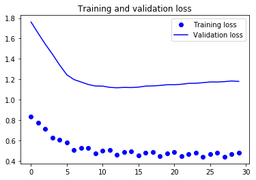

```python
loss = history.history['loss']
val_loss = history.history['val_loss']

epochs = range(len(loss))

plt.figure()

plt.plot(epochs, loss, 'bo', label='Training loss')
plt.plot(epochs, val_loss, 'b', label='Validation loss')
plt.title('Training and validation loss')
plt.legend()

plt.show()
```

```python
from IPython.display import SVG
from keras.utils.vis_utils import model_to_dot

SVG(model_to_dot(model).create(prog='dot', format='svg'))
```

```python
model.summary()
```

```
_________________________________________________________________
Layer (type)                 Output Shape              Param #
=================================================================
gru_1 (GRU)                  (None, 10)                450
_________________________________________________________________
dense_1 (Dense)              (None, 1)                 11
=================================================================
Total params: 461
Trainable params: 461
Non-trainable params: 0
_________________________________________________________________
```

**More Advanced GRU**

```python
from keras.models import Sequential
from keras import layers
from keras.optimizers import RMSprop
tb_callback = TensorBoard(log_dir="/Users/catherineordun/Documents/Scripts/log/pertussis_gru_adv",
                          histogram_freq=0, write_graph=True, write_images=True)
model = Sequential()
model.add(layers.GRU(10, input_shape=(None, ts_matrix.shape[-1])))
model.add(layers.Dense(1))
model.add(layers.Dense(1))
model.add(layers.Dense(1))
model.compile(optimizer=RMSprop(lr = 0.03), loss='mae')
history = model.fit_generator(train_gen,
                              steps_per_epoch=30,
                              epochs=150,
                              validation_data=val_gen,
                              validation_steps=val_steps, callbacks=[tb_callback])
```

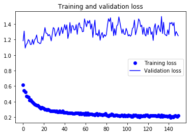

```python
loss = history.history['loss']
val_loss = history.history['val_loss']

epochs = range(len(loss))

plt.figure()

plt.plot(epochs, loss, 'bo', label='Training loss')
plt.plot(epochs, val_loss, 'b', label='Validation loss')
plt.title('Training and validation loss')
plt.legend()

plt.show()
```

```python
SVG(model_to_dot(model).create(prog='dot', format='svg'))
```

[figure not shown]

```python
model.summary()
```

```
_________________________________________________________________
Layer (type)                 Output Shape              Param #
=================================================================
gru_2 (GRU)                  (None, 10)                450
_________________________________________________________________
dense_2 (Dense)              (None, 1)                 11
_________________________________________________________________
dense_3 (Dense)              (None, 1)                 2
_________________________________________________________________
dense_4 (Dense)              (None, 1)                 2
=================================================================
Total params: 465
Trainable params: 465
Non-trainable params: 0
_________________________________________________________________
```

**GRU** with dropout. Maybe this will converge the training and validation.

- `dropout`: Float between 0 and 1. Fraction of the units to drop for the linear transformation of the inputs.
- `recurrent_dropout`: Float between 0 and 1. Fraction of the units to drop for the linear transformation of the recurrent state.

```python
from keras.models import Sequential
from keras import layers
from keras.optimizers import RMSprop

tb_callback = TensorBoard(log_dir="/Users/catherineordun/Documents/Scripts/log/pertussis_gru_adv_dropout",
                          histogram_freq=0, write_graph=True, write_images=True)
model = Sequential()
model.add(layers.GRU(20,
                     dropout=0.3,
                     recurrent_dropout=0.2,
                     input_shape=(None, ts_matrix.shape[-1])))
model.add(layers.Dense(1, activation='relu'))
model.add(layers.Dense(1))
model.compile(optimizer=RMSprop(lr=0.005), loss='mae')
history = model.fit_generator(train_gen,
                              steps_per_epoch=30,
                              epochs=50,
                              validation_data=val_gen,
                              validation_steps=val_steps, callbacks=[tb_callback])
```

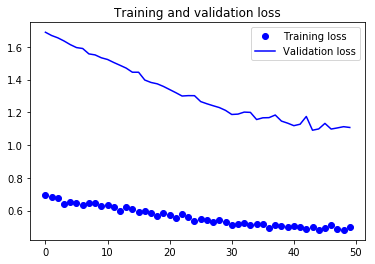

```python
loss = history.history['loss']
val_loss = history.history['val_loss']

epochs = range(len(loss))

plt.figure()

plt.plot(epochs, loss, 'bo', label='Training loss')
plt.plot(epochs, val_loss, 'b', label='Validation loss')
plt.title('Training and validation loss')
plt.legend()

plt.show()
```

```python
SVG(model_to_dot(model).create(prog='dot', format='svg'))
```

[figure not shown]

```python
model.summary()
```

```
_________________________________________________________________
Layer (type)                 Output Shape              Param #
=================================================================
gru_6 (GRU)                  (None, 20)                1500
_________________________________________________________________
dense_11 (Dense)             (None, 1)                 21
_________________________________________________________________
dense_12 (Dense)             (None, 1)                 2
=================================================================
Total params: 1,523
Trainable params: 1,523
Non-trainable params: 0
_________________________________________________________________
```

CHOLLET

- Adjust the number of units in each recurrent layer in the stacked setup. Our current choices are largely arbitrary and thus likely suboptimal.
- Adjust the learning rate used by our RMSprop optimizer.
- Try using LSTM layers instead of GRU layers.
- Try using a bigger densely-connected regressor on top of the recurrent layers, i.e. a bigger Dense layer or even a stack of Dense layers.
- Don't forget to eventually run the best performing models (in terms of validation MAE) on the test set! Least you start developing architectures that are overfitting to the validation set.

**Initial LSTM with no Dropout**

```python
from keras.layers import LSTM
tb_callback = TensorBoard(log_dir='/Users/catherineordun/Documents/Scripts/log/pertussis_lstm', histogram_freq=0, write_graph=True, write_images=True)
model= Sequential()
model.add(layers.LSTM(10,input_shape=(None, ts_matrix.shape[-1])))
model.add(Dense (1, activation ='tanh'))
model.compile(optimizer='rmsprop', loss='mae')

history = model.fit_generator(train_gen,
                    steps_per_epoch=30,
                    epochs=30,
                    validation_data=val_gen,
                    validation_steps=val_steps, callbacks=[tb_callback])
```

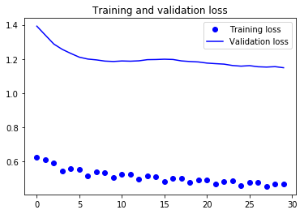

```python
loss = history.history['loss']
val_loss = history.history['val_loss']

epochs = range(len(loss))

plt.figure()

plt.plot(epochs, loss, 'bo', label='Training loss')
plt.plot(epochs, val_loss, 'b', label='Validation loss')
plt.title('Training and validation loss')
plt.legend()

plt.show()
```

```python
from IPython.display import SVG
from keras.utils.vis_utils import model_to_dot

SVG(model_to_dot(model).create(prog='dot', format='svg'))
```

```python
model.summary()
```

```
_________________________________________________________________
Layer (type)                 Output Shape              Param #
=================================================================
lstm_1 (LSTM)                (None, 10)                600
_________________________________________________________________
dense_14 (Dense)             (None, 1)                 11
=================================================================
Total params: 611
Trainable params: 611
Non-trainable params: 0
_________________________________________________________________
```

**More Advanced LSTM with Dropout**

```python
from keras.layers import LSTM
tb_callback = TensorBoard(log_dir='/Users/catherineordun/Documents/Scripts/log/pertussis_lstm_dropout', histogram_freq=0, write_graph=True, write_images=True)
model= Sequential()
model.add(layers.LSTM(10,
                     dropout=0.3,
                     recurrent_dropout=0.2,
                     input_shape=(None, ts_matrix.shape[-1])))
model.add(Dense (2, activation ='tanh'))
model.add(Dense (1))
model.compile(optimizer='rmsprop', loss='mae')

history = model.fit_generator(train_gen,
                    steps_per_epoch=30,
                    epochs=50,
                    validation_data=val_gen,
                    validation_steps=val_steps, callbacks=[tb_callback])
```

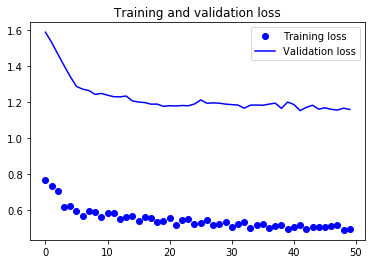

```python
loss = history.history['loss']
val_loss = history.history['val_loss']

epochs = range(len(loss))

plt.figure()

plt.plot(epochs, loss, 'bo', label='Training loss')
plt.plot(epochs, val_loss, 'b', label='Validation loss')
plt.title('Training and validation loss')
plt.legend()

plt.show()
```

```python
SVG(model_to_dot(model).create(prog='dot', format='svg'))
```

[figure not shown]

```python
model.summary()
```

```
_________________________________________________________________
Layer (type)                 Output Shape              Param #
=================================================================
lstm_7 (LSTM)                (None, 10)                600
_________________________________________________________________
dense_31 (Dense)             (None, 2)                 22
_________________________________________________________________
dense_32 (Dense)             (None, 1)                 3
=================================================================
Total params: 625
Trainable params: 625
Non-trainable params: 0
_________________________________________________________________
```

```python
from keras.models import load_model
model.save('pertussis_lstm_dropout_12302017.h5')  # creates a HDF5 file 'my_model.h5'
```

# LSTM STATEFUL

Reference: http://www.willfleury.com/machine-learning/forecasting/lstm/2017/09/01/short-term-forceasting-lstm.html

- In Keras there are two types of LSTM configurations. One is called `stateful` and the other `non stateful`. This terminology can be confusing as after all, **the very reason for using LSTMs is their temporal memory (i.e. state)**. This is different to what the term stateful in the LSTM configuration in Keras means.
- A **stateful** Keras LSTM network is one where the internal LSTM units are not reset at all during a training epoc (in fact even between epocs one must manually reset them). This means that the LSTMs build and keep state for the entire training set which means the data must be played through in order. While this is desirable to learn longer term temporal features and dependencies it can be problematic if we have a certain temporal window we want to focus on.
- A **non stateful** LSTM in Keras terminology resembles more of a classic sliding window approach to training, except where the successive timesteps in the window are framed one after another as a two dimensional array instead of flattened out into a long one dimensional array. This allows the LSTM to learn the state and temporal dependencies between the frames in the time window and Keras will automatically reset the state between each training window. This means that there is no ordering or continuity requirements on the training data outside of the windows.